# Take_home_exercise_Wei_Part1

```python
import pandas as pd
import numpy as np
import seaborn as sns; sns.set()
import matplotlib.pyplot as plt
```

## Prep the data for plotting

```python
%matplotlib inline

# read in the sample data
df = pd.read_csv("/Users/wei/Downloads/city_ops_exercise.csv")
df.date = pd.to_datetime(df.date)

#calculate the ratio between Opendoor listings and MLS listings
df['od2mls_listings'] = df['od_listings']/df['mls_listings']

#calculate the ratio between Opendoor contracts and MLS contracts
df['od2mls_contracts'] = df.od_contracts/df.mls_listings

#calculate the ratio between home visits and listings
df['od_visits_per_listing'] = df.od_home_visits/df.od_listings

#calculate the ratio between home visits and contracts
df['od_visits_per_contract'] = df.od_home_visits/df.od_contracts

#calculate the ratio between opendoor listings tocontracts
df['od_contract_per_listing'] = df.od_contracts/df.od_listings

#calculate the ratio between mls listings tocontracts
df['mls_contract_per_listing'] = df.mls_contracts/df.mls_listings
```

## Postive signals

Our listing market share has increased steadily in 2017 in all four zip codes for homes under $200k.

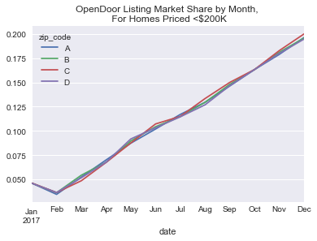

```python
#Calculate Monthly listings by zip_code, priced at <$200K
df_monthly = df[df.price_band=='<$200K'].groupby(['date', 'zip_code'])['od_listings','mls_listings'].sum()\
.unstack().asfreq('M', 'ffill').stack()
df_monthly['listing_market_share'] = df_monthly.od_listings/df_monthly.mls_listings
df_monthly['listing_market_share'].unstack().plot( title = 'OpenDoor Listing Market Share by Month, \n For Homes Priced <$200K',
                                                 xlim=['2017-01-10','2017-12-30'])
```

Resale strength is strong for homes under $200k in zipcode A. (Measured by OpenDoor’s resale contracts in proportion to MLS resale contracts)

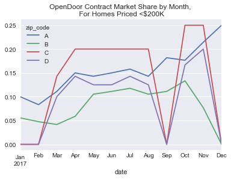

```python
#Calculate Monthly contracts by zip_code, priced at <$200K
df_contract_monthly_200kless = df[df.price_band=='<$200K'].groupby(['date', 'zip_code'])['od_contracts','mls_contracts'].sum()\
.unstack().asfreq('M', 'ffill').stack()

df_contract_monthly_200kless['contracts_market_share'] = df_contract_monthly_200kless.od_contracts/df_contract_monthly_200kless.mls_contracts

df_contract_monthly_200kless['contracts_market_share'].unstack().plot( title = 'OpenDoor Contract Market Share by Month, \n For Homes Priced <$200K',
                                                 xlim=['2017-01-10','2017-12-30'])
```

Overall listing counts declined in all four zip_codes.

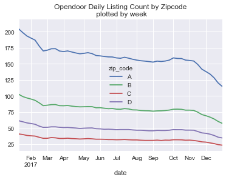

```python
#Opendoor Daily Listings by market
df.pivot_table(index='date', columns = 'zip_code', values='od_listings', aggfunc=sum ).\
resample('7D').mean().plot(title='Opendoor Daily Listing Count by Zipcode\n plotted by week',
                           xlim=['2017-01-10','2017-12-30'])
```

The gains in listing counts for homes priced under 200K were offset by larger declines in listings for homes priced $200K and more.

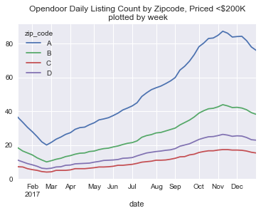

```python
#Opendoor Daily Listings for price band <$200K
df[df.price_band=='<$200K'].pivot(index='date',
                                columns = 'zip_code',
                                values='od_listings').\
resample('7D').mean().plot(title='Opendoor Daily Listing Count by Zipcode, Priced <$200K\n plotted by week',
                           xlim=['2017-01-10','2017-12-30'])
```

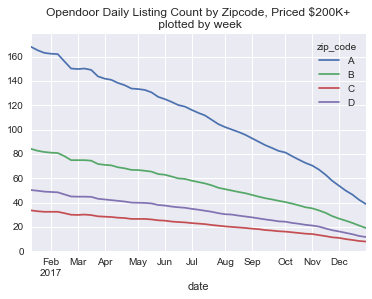

```python
#Opendoor Daily Listings for price band $200K+
df[df.price_band=='$200K+'].pivot(index='date',
                                        columns = 'zip_code',
                                        values='od_listings').\
resample('7D').mean().plot(title='Opendoor Daily Listing Count by Zipcode, Priced $200K+\n plotted by week',
                           xlim=['2017-01-10','2017-12-30'])
```

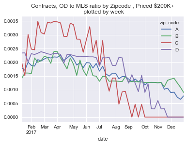

```python
# Contracts, OD to MLS ratio by Zipcode , Priced $200K+
df[df.price_band=='$200K+'].pivot(index='date', columns = 'zip_code', values='od2mls_contracts' ).\
resample('7D').mean().plot(title='Contracts, OD to MLS ratio by Zipcode , Priced $200K+\n plotted by week',
                           xlim=['2017-01-10','2017-12-30'])
```

Our listing market share has decreased in 2007 in all four zip codes for homes over $200k.

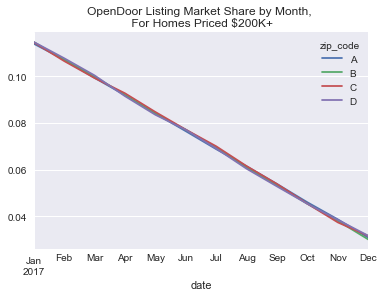

```python
#Calculate Monthly listings by zip_code, priced at $200K+
df_listing_200more = df[df.price_band=='$200K+'].groupby(['date', 'zip_code'])['od_listings','mls_listings'].sum()\
.unstack().asfreq('M', 'ffill').stack()
df_listing_200more['listing_market_share'] = df_listing_200more.od_listings/df_listing_200more.mls_listings
df_listing_200more['listing_market_share'].unstack().plot( title = 'OpenDoor Listing Market Share by Month, \n For Homes Priced $200K+',
                                                 xlim=['2017-01-10','2017-12-30'])
```

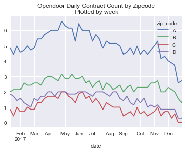

```python
#Opendoor Daily Contracts by zipcode
df.pivot_table(index='date',
               columns = 'zip_code',
               values='od_contracts',
               aggfunc=sum ).\
resample('7D').mean().plot(title='Opendoor Daily Contract Count by Zipcode\n Plotted by week',
                           xlim=['2017-01-10','2017-12-30'])
```

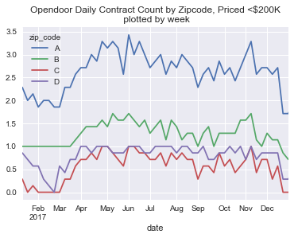

```python
# Opendoor Daily Contracts by zipcode, priced <$200K
df[df.price_band=='<$200K'].pivot(index='date',
                                        columns = 'zip_code',
                                        values='od_contracts' ).\
resample('7D').mean().plot(title='Opendoor Daily Contract Count by Zipcode, Priced <$200K\n plotted by week',
                           xlim=['2017-01-10','2017-12-30'])
```

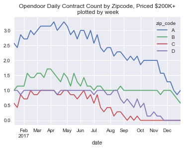

```python
# Opendoor Daily Contracts by zipcode, priced $200K+
df[df.price_band=='$200K+'].pivot(index='date',
                                        columns = 'zip_code',
                                        values='od_contracts' ).\
resample('7D').mean().plot(title='Opendoor Daily Contract Count by Zipcode, Priced $200K+\n plotted by week',
                           xlim=['2017-01-10','2017-12-30'])
```

In the second half of 2017, the conversion ratio from listing to contract declined in both Zipcode C & D for homes over $200k.

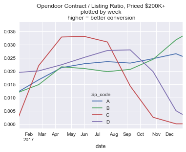

```python
# Opendoor Contract / Listing Ratio, Priced $200k+
df[df.price_band=='$200K+'].pivot(index='date',
                                        columns = 'zip_code',
                                        values='od_contract_per_listing').\
resample('7W').mean().plot(title='Opendoor Contract / Listing Ratio, Priced $200K+\
\nplotted by week\n higher = better conversion',
                           xlim=['2017-01-10','2017-12-30'])
```

The conversion rate from listing to contract declined in the second half for all four zipcodes.

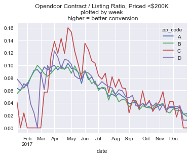

```python
# Opendoor Contract / Listing Ratio, Priced <$200K
df[df.price_band=='<$200K'].pivot(index='date',
                                  columns = 'zip_code',
                                  values='od_contract_per_listing').\
resample('7D').mean().plot(title='Opendoor Contract / Listing Ratio, Priced <$200K\
\nplotted by week\n higher = better conversion',
                           xlim=['2017-01-10','2017-12-30'])
```

We are getting less visits for homes over $200K

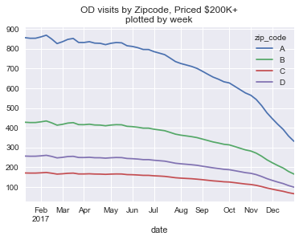

```python
#OD visits by Zipcode, Priced $200K+
df[df.price_band=='$200K+'].pivot(index='date', columns = 'zip_code', values='od_home_visits' ).\
resample('7D').mean().plot(title='OD visits by Zipcode, Priced $200K+\nplotted by week',
                                                 xlim=['2017-01-10','2017-12-30'])
```

## Others

```python
# Opendoor Total contracts by market, $200k+
df[df.price_band=='$200K+'].pivot(index='date', columns = 'zip_code', values='od_contracts').\
resample('M').sum()
```

| zip_code date | A | B | C | D |
| --- | --- | --- | --- | --- |
| 2017-01-31 | 64 | 27 | 14 | 24 |
| 2017-02-28 | 79 | 38 | 23 | 28 |
| 2017-03-31 | 96 | 48 | 30 | 31 |
| 2017-04-30 | 94 | 44 | 28 | 29 |
| 2017-05-31 | 93 | 44 | 27 | 31 |
| 2017-06-30 | 88 | 37 | 26 | 30 |
| 2017-07-31 | 79 | 33 | 17 | 30 |
| 2017-08-31 | 71 | 32 | 9 | 27 |
| 2017-09-30 | 62 | 30 | 2 | 18 |
| 2017-10-31 | 62 | 31 | 1 | 13 |
| 2017-11-30 | 54 | 29 | 0 | 4 |
| 2017-12-31 | 35 | 26 | 0 | 0 |
| 2018-01-31 | 7 | 6 | 0 | 0 |

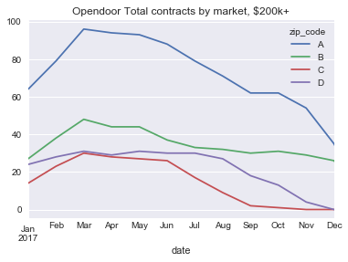

```python
df[df.price_band=='$200K+'].pivot(index='date', columns = 'zip_code', values='od_contracts').\
resample('M').sum().plot(title='Opendoor Total contracts by market, $200k+',xlim=['2017-01-10','2017-12-30'])
```

```python
# MLS Total contracts by market, <$200k
df[df.price_band=='<$200K'].pivot(index='date',
                                  columns = 'zip_code',
                                  values='mls_contracts').\
resample('M').sum()
```

| zip_code date | A | B | C | D |
| --- | --- | --- | --- | --- |
| 2017-01-31 | 535 | 471 | 136 | 202 |
| 2017-02-28 | 635 | 556 | 160 | 238 |
| 2017-03-31 | 733 | 644 | 184 | 277 |
| 2017-04-30 | 672 | 591 | 169 | 253 |
| 2017-05-31 | 631 | 552 | 158 | 236 |
| 2017-06-30 | 587 | 514 | 146 | 222 |
| 2017-07-31 | 525 | 459 | 134 | 197 |
| 2017-08-31 | 551 | 485 | 140 | 209 |
| 2017-09-30 | 476 | 416 | 122 | 181 |
| 2017-10-31 | 500 | 440 | 126 | 189 |
| 2017-11-30 | 450 | 393 | 115 | 168 |
| 2017-12-31 | 355 | 310 | 88 | 131 |
| 2018-01-31 | 55 | 49 | 15 | 20 |

[figure not shown]

```python
# MLS Contract / Listing Ratio, Priced <$200K
df[df.price_band=='<$200K'].pivot(index='date',
                                  columns = 'zip_code',
                                  values='mls_contract_per_listing').\
resample('7D').mean().plot(title='MLS Contract / Listing Ratio, Priced <$200K\
\nplotted by week\n higher = better conversion',
                           xlim=['2017-01-10','2017-12-30'])
```

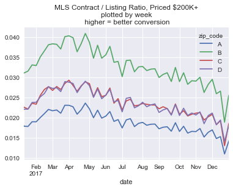

```python
# MLS Contract / Listing Ratio, Priced $200K+
df[df.price_band=='$200K+'].pivot(index='date',
                                  columns = 'zip_code',
                                  values='mls_contract_per_listing').\
resample('7D').mean().plot(title='MLS Contract / Listing Ratio, Priced $200K+\
\nplotted by week\n higher = better conversion',
                           xlim=['2017-01-10','2017-12-30'])
```

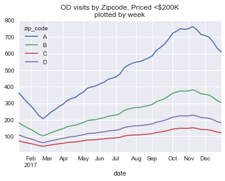

```python
#OD visits by Zipcode, Priced <$200K
df[df.price_band=='<$200K'].pivot(index='date', columns = 'zip_code', values='od_home_visits' ).\
resample('7D').mean().plot(title='OD visits by Zipcode, Priced <$200K\nplotted by week',
                                                 xlim=['2017-01-10','2017-12-30'])
```

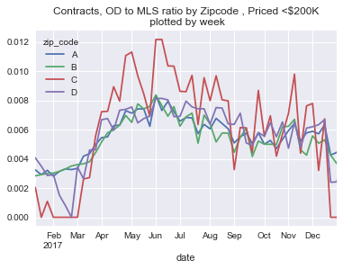

```python
# Contracts, OD to MLS ratio by Zipcode , Priced <$200K
df[df.price_band=='<$200K'].pivot(index='date', columns = 'zip_code', values='od2mls_contracts' ).\
resample('7D').mean().plot(title='Contracts, OD to MLS ratio by Zipcode , Priced <$200K\n plotted by week',
                           xlim=['2017-01-10','2017-12-30'])
```

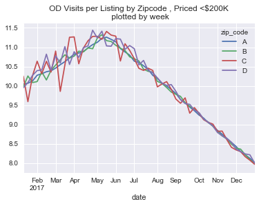

```python
# OD Visits per Listing by Zipcode , Priced <$200K
df[df.price_band=='<$200K'].pivot(index='date', columns = 'zip_code', values='od_visits_per_listing' ).\
resample('7D').mean().plot(title='OD Visits per Listing by Zipcode , Priced <$200K\n plotted by week',
                           xlim=['2017-01-10','2017-12-30'])
```

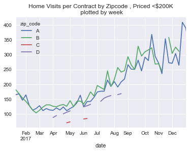

```python
#Home Visits per Contract by Zipcode , Priced <$200K
df[df.price_band=='<$200K'].pivot(index='date', columns = 'zip_code', values='od_visits_per_contract' ).\
resample('7D').mean().plot(title='Home Visits per Contract by Zipcode , Priced <$200K\n plotted by week',
                           xlim=['2017-01-10','2017-12-30'])
```

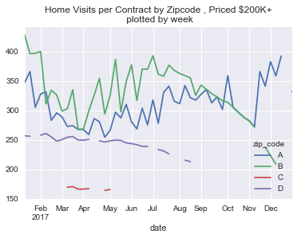

```python
#Home Visits per Contract by Zipcode , Priced <$200K
df[df.price_band=='$200K+'].pivot(index='date', columns = 'zip_code', values='od_visits_per_contract' ).\
resample('7D').mean().plot(title='Home Visits per Contract by Zipcode , Priced $200K+\n plotted by week',
                           xlim=['2017-01-10','2017-12-30'])
```